# Authentic Montessori survey

### Staffing model (e.g., teacher plus assistant vs. co-teachers, etc.)

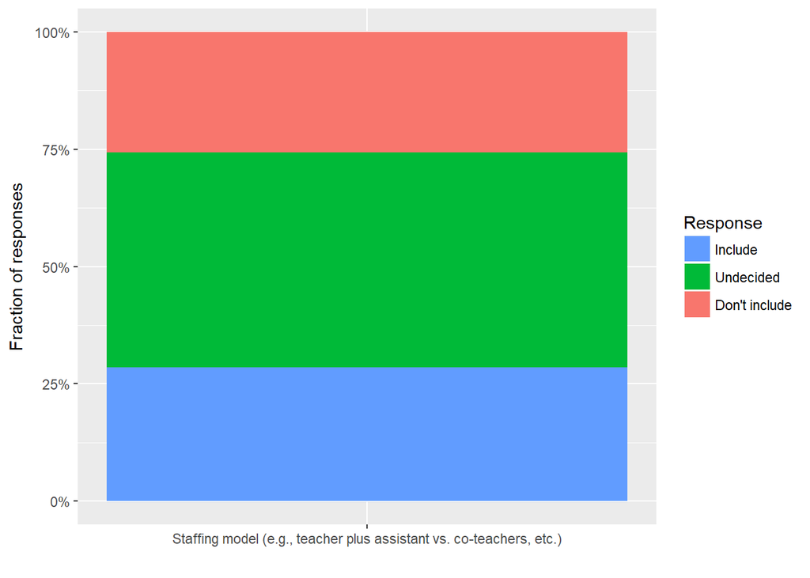

- Co-teachers seems important to Wildflower culture, but maybe not to “authentic Montessori”?
- The WF co-teaching, nonhierarchical model is different than the typical Montessori classroom and I’m not sure that this is our definition of “authentic” Montessori
- Same as student numbers.
- I have seen such a variety of models work, that becoming prescriptive might become restrictive.
- This is another area that I think can be flexible. While the traditional Montessori classroom has a lead and an assistant, I strongly believe the co-teaching model works very successfully for many schools (and in Wildflower schools in particular). Can we be flexible about each individual location?
- Seems like the network is slightly unconventional in terms of how it offers staffing in relation to AMI guidelines, which recommend 1 teacher only and 1 or more assistants.
- If we want to attract AMI trained teachers then we should be cautious about this language - co teaching isn’t part of the AMI training
- I think the important thing here is trained, experienced staff who work in collaboration with one another.
- Our bilingual model requires coteaching
- Since WF will have different models, it might be interesting to expand upon this idea.
- I’ve worked in both situations: lead/assistant and co-teacher. I think it can work both ways. Personality and good communication are most important to me.
- Wildflower seems to be pushing the boundary of this guideline, particularly when it comes to AMI’s ideal classroom structure. I’m actually very curious to see how it works to have two co-teachers and no assistant, and would encourage us to leave flexibility around this in our own definition at the moment
- This is not part of Montessori’s idea, but more the teal organization model. Some schools with aftercare program may still hire assistant to help with the cost control. That’s another issue we need to talk about during the “teal” talk.

### Length of day

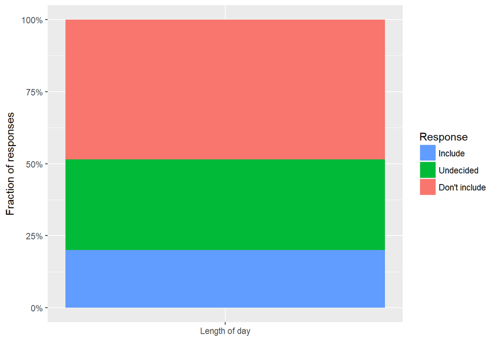

- Diff for diff planes.
- Implied in the question about work cycle. I assume you’d ask how many work cycles and how long each work cycle is
- how would this be articulated?
- Again, all schools have different lengths. Some of these more school specific questions might be grouped together so parents can browse how the diffferences and similiarities in teh programs.
- Length of work cycle rather than length of day
- what’s the difference between this one and the length of work hours?